# Terraceamento e Controle da Erosão Hídrica

Bioengenharia de Solos

Prof. Dr. Luiz Diego Vidal Santos

## Abertura Planejamento Conservacionista e Terraços

Objetivo da aula Seleção e dimensionamento

Selecionar práticas conservacionistas pela função no sistema e calcular espaçamento e requisitos hidráulicos de terraços agrícolas.

Sequência do projeto Encadeamento lógico

Capacidade de uso → cobertura e controle do escoamento → espaçamento ($EV$ e $EH$) → seção e saída → implantação e manutenção.

Práticas Vegetativas Práticas Edáficas Práticas Mecânicas

O terraço integra o sistema conservacionista na escala da microbacia: não substitui a cobertura vegetal nem dispensa saída hidráulica estabilizada.

# Práticas e função no sistema

## Sistema Combinar Práticas Vegetativas, Edáficas e Mecânicas

| Grupo | Exemplos | Função predominante |
| --- | --- | --- |
| **Vegetativas** | Cobertura, faixas e cordões vegetativos | Proteger a superfície e reduzir concentração |
| **Edáficas e de manejo** | Rotação, aporte orgânico, correções indicadas e tráfego controlado | Melhorar as condições do solo |
| **Mecânicas** | Terraços, canais e bacias dimensionados | Interceptar, armazenar ou conduzir água |

Uma prática mecânica não dispensa cobertura nem planejamento do uso. Avalie também estradas e contribuições externas ao talhão.

## Diagnóstico Escolher a partir da Aptidão e da Capacidade de Uso

**1. Levantamento físico:** relevo, profundidade, drenagem, erodibilidade e impedimentos.

**2. Compatibilidade:** compare o uso proposto à capacidade de sustentá-lo.

**3. Áreas sensíveis:** preserve áreas de função hídrica e ecológica.

**4. Zoneamento:** defina unidades de manejo com características semelhantes.

**5. Rede de drenagem:** mapeie caminhos preferenciais e saída da água.

Critério de decisão Mudança de uso vs. obras

Há situações em que **alterar o uso da terra** é mais adequado e seguro do que intensificar obras mecânicas para tentar manter uma atividade incompatível com a aptidão do solo.

## Planejamento Sistema de Capacidade de Uso das Terras (Classes I–VIII) e Microbacias

| Grupo / Classes | Aptidão e Limitações | Diretriz de Manejo e Bioengenharia |
| --- | --- | --- |
| **Grupo A (I a IV)** | Culturas anuais (I sem restrição; II–III restrições moderadas a severas; IV uso ocasional) | Práticas edáficas + vegetativas (I–II) associadas a **terraceamento e canais escoadouros** (III–IV) |
| **Grupo B (V a VII)** | Pastagens, silvicultura e culturas perenes (declividade alta, pedregosidade ou drenagem restrita) | Cobertura permanente, **cordões vegetativos, faixas de vetiver** e controle de carga animal |
| **Grupo C (VIII)** | Terras impróprias para exploração agropecuária (escarpas, afloramentos, APPs) | Preservação integral, **PRAD e estabilização biotécnica** |

**Unidade de planejamento:** o projeto conservacionista deve ser integrado na escala da **Microbacia Hidrográfica** (conectando estradas rurais, divisores de água, encostas e rede de drenagem).

## Base Práticas Edáficas e Vegetativas na Base do Sistema

Práticas edáficas Estrutura, agregação e infiltração

- **Calagem e gessagem:** floculação de argilas e aprofundamento radicular.
- **Nutrição e matéria orgânica:** adubação orgânica e equilíbrio nutricional para rápido fechamento do dossel.
- **Descompactação pontual:** subsolagem ou escarificação em solo friável apenas quando houver camada compactada diagnosticada ($RP > 2{,}0\text{ MPa}$).

Práticas vegetativas Energia cinética, fatores $C$ e $L$

- **SPD e cultivo mínimo:** manutenção de palhada permanente ($\ge 70\%$ de cobertura), rotação de culturas e **adubação verde** (leguminosas + gramíneas).
- **Barreiras vivas e eólica:** cultivo em contorno, faixas de retenção, **cordões vegetativos** (*Chrysopogon zizanioides*, *Pennisetum*, leguminosas arbustivas) e **quebra-ventos** contra erosão eólica.

# Terraços em nível e em gradiente

## Tipologia Retenção e Condução Exigem Critérios Diferentes

| Tipo | Destino principal da água | Verificações obrigatórias |
| --- | --- | --- |
| **Em nível** | Armazenamento temporário e infiltração | Volume útil, infiltração, estabilidade e rota de excedência |
| **Em gradiente** | Condução a uma saída protegida | Vazão, geometria, erosão e conexão com o canal |

Limitação física Infiltração e saturação

Baixa infiltração ou saturação prolongada podem limitar estruturas de retenção em nível, exigindo escoamento controlado.

Critério pedológico Sem automatismos

O nome da classe pedológica, sozinho, não impõe uma proibição nem uma escolha automática: avalie atributos hidráulicos e locais.

## Geometria Geometria e Espaçamento dos Terraços

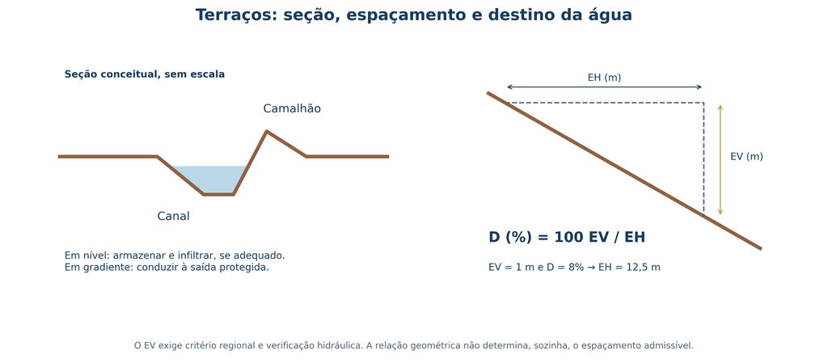

Terraço em corte e relações entre espaçamento vertical e horizontal

Terraço em corte transversal e relações entre espaçamento vertical ($EV$) e horizontal ($EH$) Compatibilização entre rampa do terreno, largura da faixa de contribuição e seção útil de retenção ou condução

## Cálculo Espaçamento Vertical e Horizontal

$$D = 100\,\frac{EV}{EH} \qquad EH = \frac{100\,EV}{D}$$

- $EV$: diferença de cota entre linhas consecutivas, em $\text{m}$.
- $EH$: distância horizontal medida na direção do declive, em $\text{m}$.
- $D$: declividade do terreno em porcentagem ($\%$).

Exemplo didático Aplicação direta

Para $D = 8\%$ e um $EV$ preliminar de $1{,}0\text{ m}$:

$$EH = \frac{100 \times 1{,}0}{8} = 12{,}5\text{ m}$$

Ressalva técnica A geometria não dimensiona sozinha

O $EV$ adotado precisa ser definido por **método regional** e verificado quanto a solo, manejo, operação e hidráulica.

## Critérios Métodos Empíricos: Declarar Origem e Limites

**1. Especificidade:** equações e tabelas de espaçamento foram desenvolvidas para condições específicas.

**2. Rastreabilidade:** registre referência, unidades, grupo de solo e fatores de cobertura ou operação.

**3. Legenda:** não transfira coeficientes de uma tabela sem verificar sua legenda original.

**4. Operação:** ajuste o traçado à topografia real e à circulação de máquinas.

**5. Validação:** submeta o espaçamento escolhido à verificação hidráulica da seção e da saída.

Atividade em aula Comparação de critérios

Aplique **dois critérios documentados** ao mesmo talhão e explique por que os valores de $EV$ e $EH$ diferem segundo solo, chuva e manejo considerados.

## Dimensionamento Quantidade de Faixas e Área de Contribuição

**Número de intervalos** (rampa horizontal de $200\text{ m}$ e $EH = 12{,}5\text{ m}$):

$$N_{\mathrm{intervalos}} = \frac{200}{12{,}5} = 16$$

O número final de obras depende dos limites da gleba e das linhas de topo e de base.

**Área de contribuição** (trecho regular com comprimento de linha de $400\text{ m}$):

$$A_b \approx 400 \times 12{,}5 = 5.000\text{ m}^2 = 0{,}50\text{ ha}$$

Contribuições externas, cabeceiras e irregularidades exigem delimitação adicional.

A delimitação real em planta deve somar qualquer escoamento oriundo de estradas ou áreas a montante antes de verificar o canal do terraço.

# Verificação hidráulica

## Em Nível Terraço em Nível: Armazenamento Útil

Se uma área de $1\text{ ha}$ produzir lâmina escoada de $30\text{ mm}$:

$$V_e = 10 \times 30 \times 1 = 300\text{ m}^3$$

Para $200\text{ m}$ de canal com seção útil uniforme:

$$A_{\mathrm{útil}} \ge \frac{300}{200} = 1{,}50\text{ m}^2$$

Cuidado na verificação Cálculo preliminar

- Considere variações de cota, sedimentação, infiltração ao longo do evento, borda livre e transbordamento seguro.
- Se a lâmina de $30\text{ mm}$ já foi estimada como **escoamento**, não desconte novamente a mesma perda por infiltração.

## Em Gradiente Terraço em Gradiente: Vazão e Descarga

No exemplo de $0{,}50\text{ ha}$, com hipóteses didáticas $C = 0{,}50$ e $i = 120\text{ mm h}^{-1}$:

$$Q_p = \frac{0{,}50 \times 120 \times 0{,}50}{360} = 0{,}0833\text{ m}^3\,\text{s}^{-1}$$

As **Aulas 07 e 08** desenvolvem a verificação da capacidade e estabilidade por **Manning**.

Requisitos hidráulicos Lista de checagem

- Dimensione a seção para a vazão e o revestimento previstos.
- Verifique velocidade ($V$) e tensão aplicada ($\tau_0$).
- Some áreas contribuintes e considere seus tempos de resposta no canal coletor.
- Construa e estabilize a **saída** antes de conectar os terraços.

## Seção Seção Transversal e Operação Agrícola

Geometria e terraplenagem Projeto da seção

- Defina canal, camalhão, fundação e cota de coroamento.
- Compatibilize largura e taludes com solo e equipamentos.
- Separe o solo superficial destinado à revegetação.

Conservação e tráfego Integridade em operação

- Especifique compactação nas zonas estruturais.
- Proteja o canal e a saída contra erosão antes das chuvas.
- Evite bloqueios e atalhos de tráfego que interrompam a continuidade.

**Atenção de orçamento:** volume de corte, volume útil de armazenamento e volume compactado são grandezas diferentes.

# Locação, implantação e desempenho

## Execução Sequência Executiva e Pontos de Controle

**1.** Levantar cotas e confirmar contribuição e saída.

**2.** Locar linhas, conexões e estruturas complementares.

**3.** Preparar o terreno e executar corte e aterro.

**4.** Conferir seção, declividade longitudinal e compactação especificada.

**5.** Implantar cobertura e proteção temporária.

**6.** Registrar o estado inicial e inspecionar após chuvas.

Manutenção corretiva O que corrigir após chuvas

- Depressões inesperadas na crista
- Erosão na descarga e conexões
- Recalques no aterro
- Rompimento do camalhão
- Acúmulo de sedimentos que reduza a seção útil

## Campo Cordões de Contorno: Observar a Função em Campo

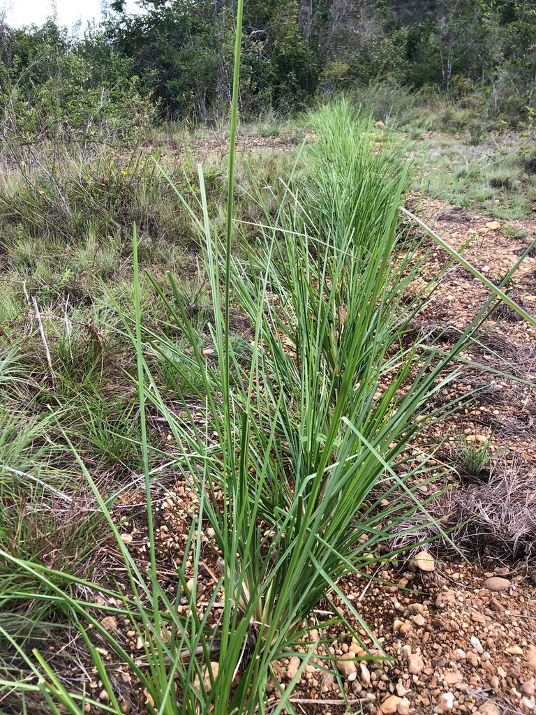

Cordão em contorno para discussão da interceptação do escoamento

Cordão em contorno Interceptação do escoamento superficial ao longo da encosta

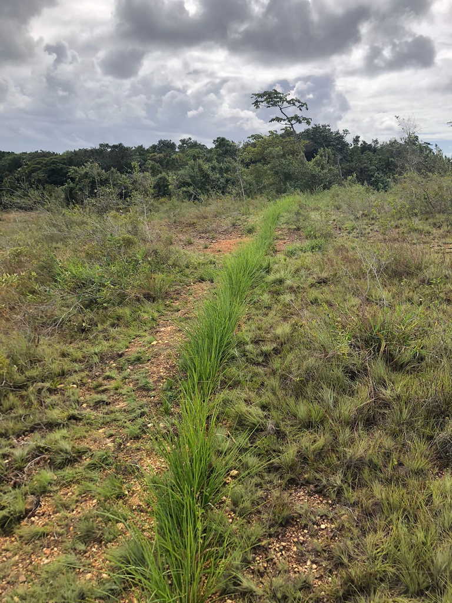

Deposição junto à barreira em contorno

Deposição a montante Retenção de sedimentos junto à barreira em contorno

## Atividade Atividade · Memorial de uma Unidade de Manejo

Entregas técnicas Conteúdo do memorial

1. Mapa de contribuição e justificativa do tipo de terraço.
2. Critério documentado de $EV$ e cálculo de $EH$.
3. Estimativa de vazão ou armazenamento e seção preliminar.
4. Traçado da saída e medidas de proteção.
5. Quantitativos, sequência de execução e plano de manutenção.

Critério de revisão Coerência sistêmica

As decisões **geométricas**, **hidráulicas** e **operacionais** precisam ser compatíveis entre si e com a capacidade de uso da unidade de manejo.

# Acervo visual · Construção e locação

## Acervo Registros e Esquemas de Apoio · 1

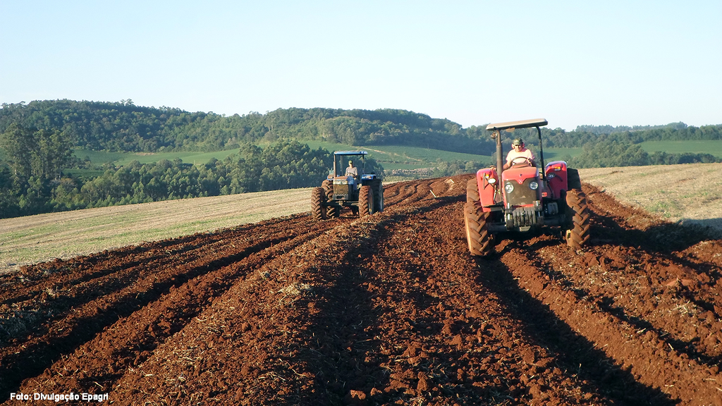

Controle de Erosão Hídrica

Controle de Erosão Hídrica

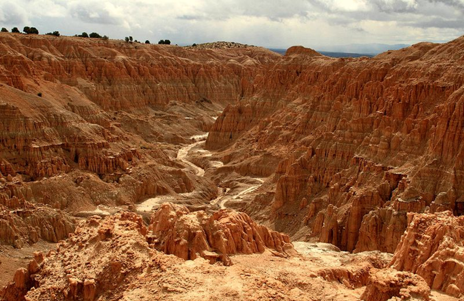

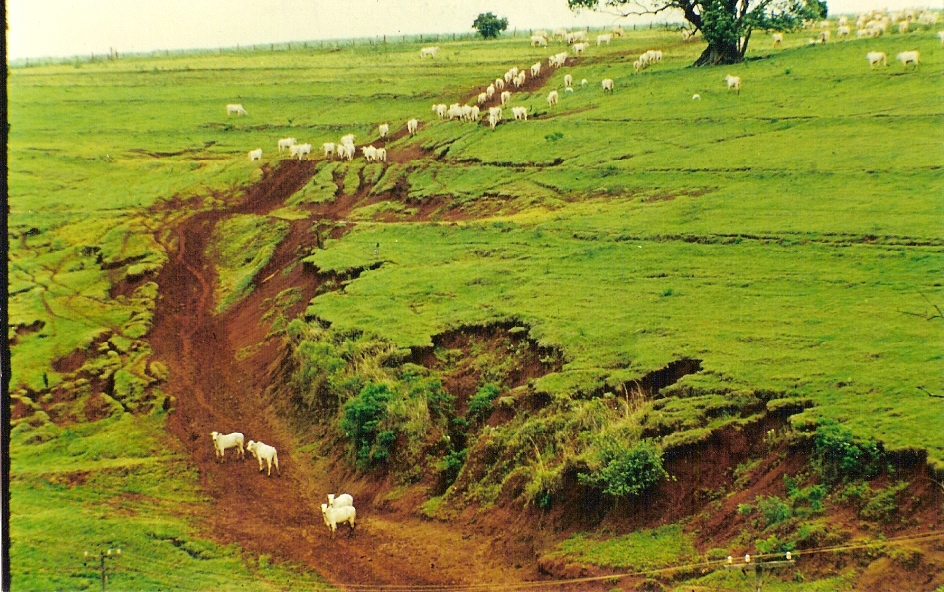

Capacidade de uso do solo

Capacidade de uso do solo

Acervo preservado da conversão original. Confira a geometria e os procedimentos com os cálculos e critérios apresentados nesta aula.

## Acervo Registros e Esquemas de Apoio · 2

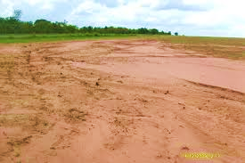

Erosividade e uso

Erosividade e uso

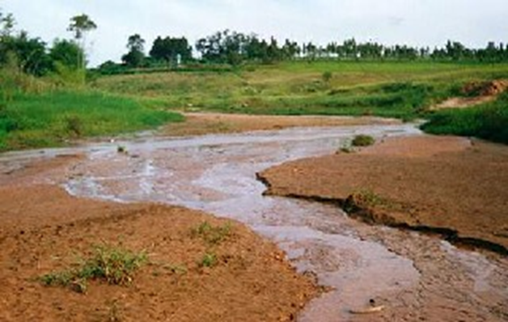

Capacidade de uso

Capacidade de uso

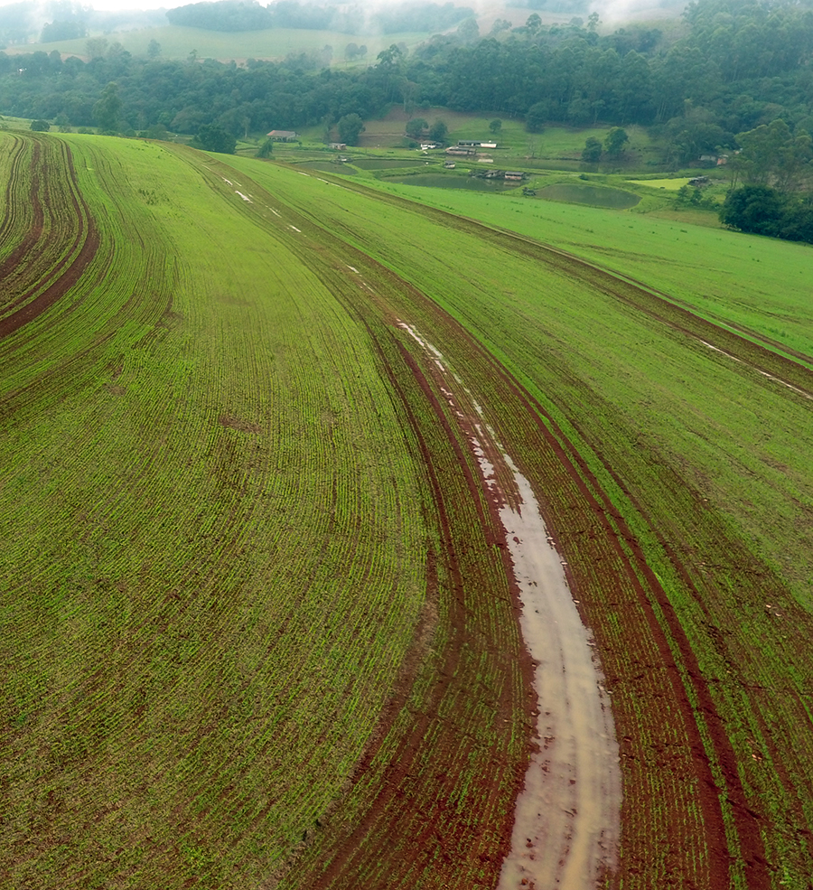

Práticas mecânicas

Práticas mecânicas

Acervo preservado da conversão original. Confira a geometria e os procedimentos com os cálculos e critérios apresentados nesta aula.

## Acervo Registros e Esquemas de Apoio · 3

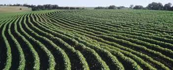

Controle da erosão

Controle da erosão

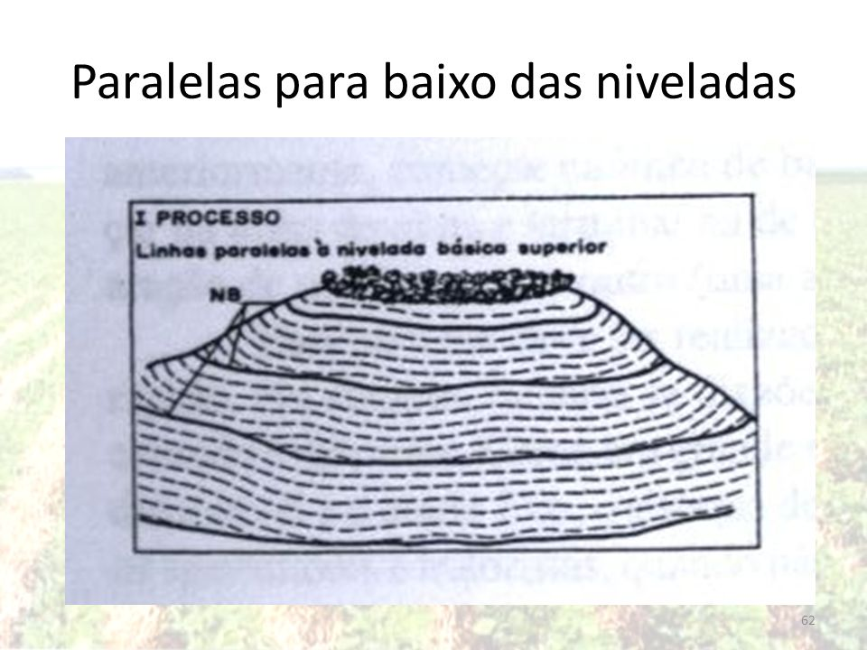

Locação de niveladas básicas

Locação de niveladas básicas

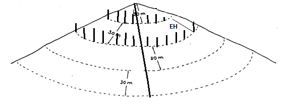

Desenho esquemático da locação de niveladas básicas

Locação de niveladas básicas (esquema)

Acervo preservado da conversão original. Confira a geometria e os procedimentos com os cálculos e critérios apresentados nesta aula.

## Acervo Registros e Esquemas de Apoio · 4

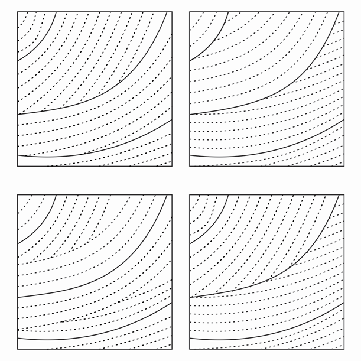

Orientação de preparo do solo

Orientação de preparo do solo

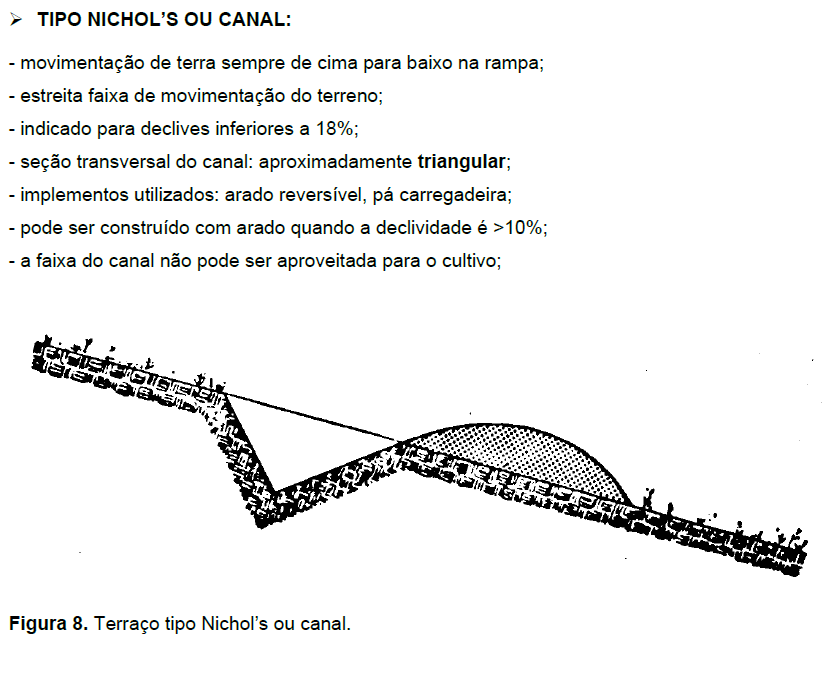

Terraceamento

Terraceamento

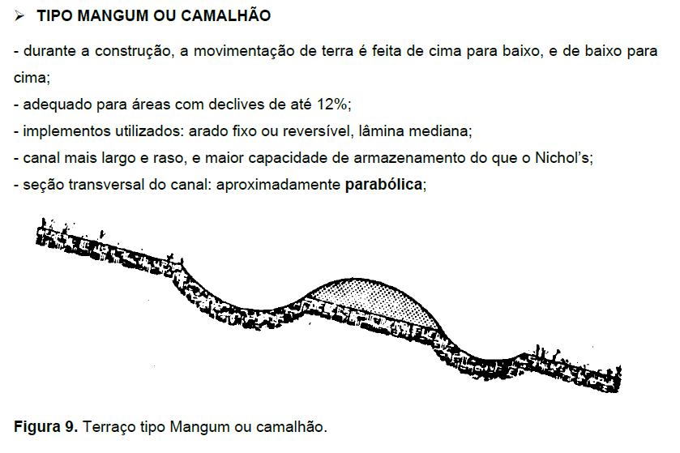

Visão esquemática do terraceamento

Visão esquemática do terraceamento

Acervo preservado da conversão original. Confira a geometria e os procedimentos com os cálculos e critérios apresentados nesta aula.

## Acervo Registros e Esquemas de Apoio · 5

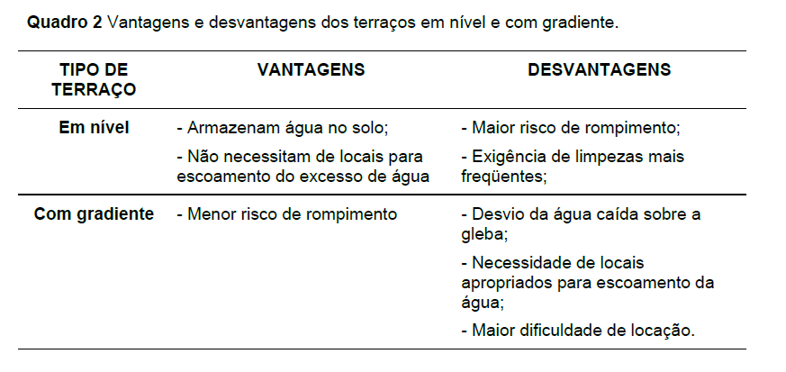

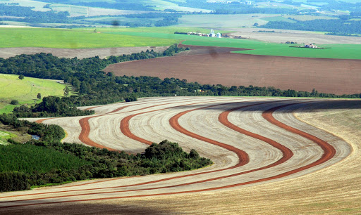

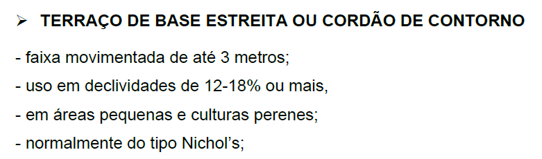

Acervo preservado da conversão original. Confira a geometria e os procedimentos com os cálculos e critérios apresentados nesta aula.

## Acervo Registros e Esquemas de Apoio · 6

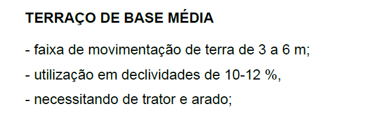

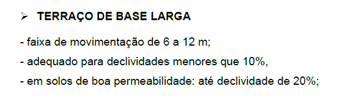

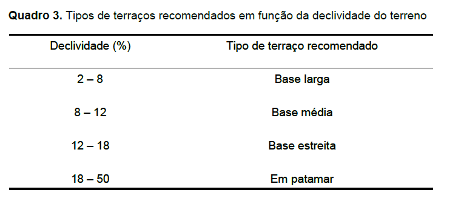

Acervo preservado da conversão original. Confira a geometria e os procedimentos com os cálculos e critérios apresentados nesta aula.

## Acervo Registros e Esquemas de Apoio · 7

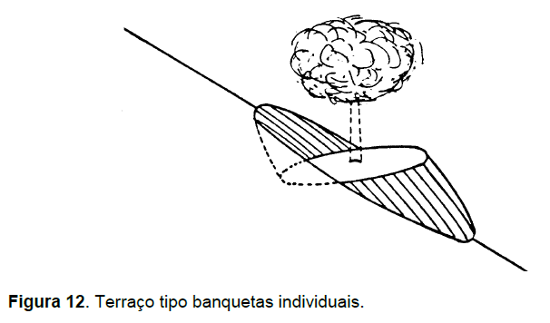

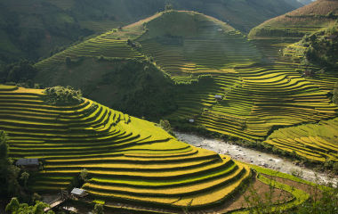

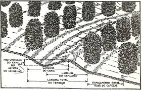

Acervo preservado da conversão original. Confira a geometria e os procedimentos com os cálculos e critérios apresentados nesta aula.

## Acervo Registros e Esquemas de Apoio · 8

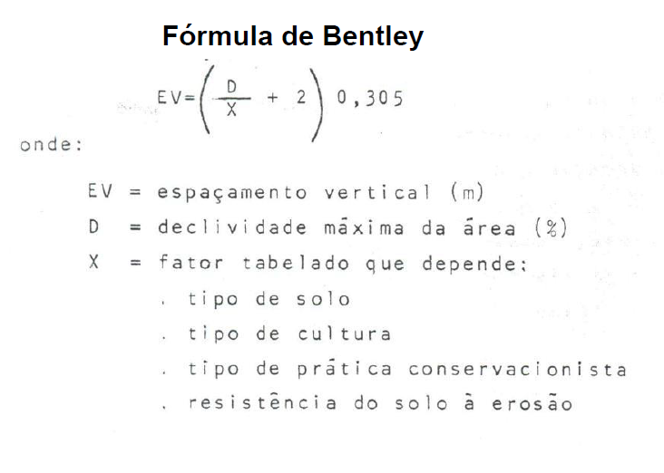

Métodos de espaçamento

Métodos de espaçamento

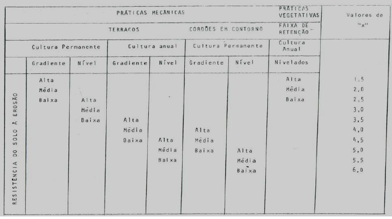

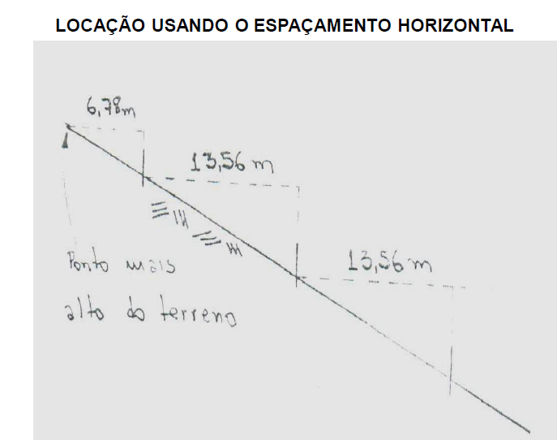

Ponto mais alto do terreno

Ponto mais alto do terreno

Acervo preservado da conversão original. Confira a geometria e os procedimentos com os cálculos e critérios apresentados nesta aula.